# p8105_hw02

James Ng

9/27/2019

# Problem 1

```r
wheel_data=
  readxl::read_xlsx("./Trash-Wheel-Collection-Totals-8-6-19.xlsx",
           sheet="Mr. Trash Wheel",
           skip = 1,
           col_names = TRUE) %>%
  janitor::clean_names() %>%
  select(dumpster:homes_powered) %>%
  drop_na(dumpster) %>%
  mutate(
    sports_balls = as.integer(sports_balls)
  )
```

```r
precip_2017=
  readxl::read_excel("./Trash-Wheel-Collection-Totals-8-6-19.xlsx",
                     sheet = "2017 Precipitation",
                     skip = 1,
                     col_names = TRUE
                     ) %>%
  janitor::clean_names() %>%
  drop_na(month) %>%
  pivot_longer(
    total,
    names_to = "year",
    values_to = "inches"
  ) %>%
  mutate(
    year = 2017,
    month = month.name
  )
precip_2018=
  readxl::read_excel("./Trash-Wheel-Collection-Totals-8-6-19.xlsx",
                     sheet = "2018 Precipitation",
                     skip = 1,
                     col_names = TRUE
                     ) %>%
  janitor::clean_names() %>%
  drop_na(month) %>%
  pivot_longer(
    total,
    names_to = "year",
    values_to = "inches"
  ) %>%
  mutate(
    year = 2018,
    month = month.name
  )
precip_total=
  bind_rows(precip_2017,precip_2018)
```

### Problem 1 Discussion

wheel_data has 344 observations and 14 variables while the final precipitation dataframe has 24 observations of 3 variables. This makes sense for the precipitation data frame since the data is the monthly precipitation for 2 years.The dataset includes many interesting information such as the median number of sports balls in 2017 was 8.5 balls and the total precipitation for 2018 was 70.33 inches.

# Problem 2

```r
pols_df=
  read_csv("./pols-month.csv") %>%
  separate(mon,into = c("year","month","day"),sep="-",remove = TRUE,extra = "warn") %>%
  janitor::clean_names() %>%
  mutate(
    month = case_when(
      month == "01"  ~ "January",
      month == "02"  ~ "February",
      month == "03"  ~ "March",
      month == "04"  ~ "April",
      month == "05"  ~ "May",
      month == "06"  ~ "June",
      month == "07"  ~ "July",
      month == "08"  ~ "August",
      month == "09"  ~ "September",
      month == "10"  ~ "October",
      month == "11"  ~ "November",
      month == "12"  ~ "December"
    )
  ) %>%
mutate(
  president=prez_gop,
  president=case_when(
    president == "0"  ~ "dem",
    president == "1"  ~ "gop",
  )
) %>%
select(-day,-prez_gop,-prez_dem)
```

```r
snp_df=
  read_csv("./snp.csv") %>%
  separate(date,into = c("month","day","year"),sep="/",remove = TRUE,extra = "warn") %>%
  janitor::clean_names() %>%
  mutate(
    month = case_when(
      month == "1"  ~ "January",
      month == "2"  ~ "February",
      month == "3"  ~ "March",
      month == "4"  ~ "April",
      month == "5"  ~ "May",
      month == "6"  ~ "June",
      month == "7"  ~ "July",
      month == "8"  ~ "August",
      month == "9"  ~ "September",
      month == "10"  ~ "October",
      month == "11"  ~ "November",
      month == "12"  ~ "December"
    )
) %>%
select(year,month,everything(),-day)
```

```r
unemploy_df=
  read_csv("./unemployment.csv") %>%
  janitor::clean_names()
un_jan= unemploy_df %>%
  select(year,jan) %>%
  pivot_longer(
    jan,
    names_to = "month",
    values_to = "unemployment_rate"
  )
un_feb= unemploy_df %>%
  select(year,feb) %>%
  pivot_longer(
    feb,
    names_to = "month",
    values_to = "unemployment_rate"
  )
un_mar= unemploy_df %>%
  select(year,mar) %>%
  pivot_longer(
    mar,
    names_to = "month",
    values_to = "unemployment_rate"
  )
un_apr= unemploy_df %>%
  select(year,apr) %>%
  pivot_longer(
    apr,
    names_to = "month",
    values_to = "unemployment_rate"
  )
un_may= unemploy_df %>%
  select(year,may) %>%
  pivot_longer(
    may,
    names_to = "month",
    values_to = "unemployment_rate"
  )
un_jun= unemploy_df %>%
  select(year,jun) %>%
  pivot_longer(
    jun,
    names_to = "month",
    values_to = "unemployment_rate"
  )
un_jul= unemploy_df %>%
  select(year,jul) %>%
  pivot_longer(
    jul,
    names_to = "month",
    values_to = "unemployment_rate"
  )
un_aug= unemploy_df %>%
  select(year,aug) %>%
  pivot_longer(
    aug,
    names_to = "month",
    values_to = "unemployment_rate"
  )
un_sep= unemploy_df %>%
  select(year,sep) %>%
  pivot_longer(
    sep,
    names_to = "month",
    values_to = "unemployment_rate"
  )
un_oct= unemploy_df %>%
  select(year,oct) %>%
  pivot_longer(
    oct,
    names_to = "month",
    values_to = "unemployment_rate"
  )
un_nov= unemploy_df %>%
  select(year,nov) %>%
  pivot_longer(
    nov,
    names_to = "month",
    values_to = "unemployment_rate"
  )
un_dec= unemploy_df %>%
  select(year,dec) %>%
  pivot_longer(
    dec,
    names_to = "month",
    values_to = "unemployment_rate"
  )
unemploy_tidy=
  bind_rows(un_jan,un_feb,un_mar,un_apr,un_may,un_jun,un_jul,un_aug,un_sep,un_oct,un_nov,un_dec) %>%
  janitor::clean_names() %>%
  mutate(
    year=as.numeric(year),
    month = case_when(
      month == "jan"  ~ "January",
      month == "feb"  ~ "February",
      month == "mar"  ~ "March",
      month == "apr"  ~ "April",
      month == "may"  ~ "May",
      month == "jun"  ~ "June",
      month == "jul"  ~ "July",
      month == "aug"  ~ "August",
      month == "sep"  ~ "September",
      month == "oct"  ~ "October",
      month == "nov"  ~ "November",
      month == "dec"  ~ "December"
    )
  )
```

```r
prob_2_df_a=
  left_join(pols_df,snp_df,by=c("year" = "year", "month" = "month")) %>%
  janitor::clean_names() %>%
  mutate(
    year=as.numeric(year)
  )
prob_2_df_full=
  left_join(prob_2_df_a,unemploy_tidy,by=c("year" = "year", "month" = "month"))
```

### Problem 2 discussion

The pols_df contained information regarding how many members of our senate, house and president belonged to which party for the years in the datasets. I’m not actually sure what the snp is supposed to be. I assume it shows the value of the snp 500 as a gauge of the economy. The last data frame shows the unemployment rate. Using the key variables of year and month, the final dataset shows the political makeup of the country and the strength of the stock market in contrast to the unemployment rate of our county.

## Problem 3

```r
baby_names=
  read_csv("./Popular_Baby_Names.csv") %>%
  janitor::clean_names() %>%
  mutate(
    ethnicity=case_when(
      ethnicity=="ASIAN AND PACI"~"ASIAN AND PACIFIC ISLANDER",
      ethnicity=="ASIAN AND PACIFIC ISLANDER"~"ASIAN AND PACIFIC ISLANDER",
      ethnicity=="WHITE NON HISPANIC"~"WHITE NON HISPANIC",
      ethnicity=="WHITE NON HISP"~"WHITE NON HISPANIC",
      ethnicity=="BLACK NON HISPANIC"~"BLACK NON HISPANIC",
      ethnicity=="BLACK NON HISP"~"BLACK NON HISPANIC",
      ethnicity=="HISP"~"HISPANIC",
      ethnicity=="HISPANIC"~"HISPANIC"
    )
  ) %>%
  distinct()

olivia=baby_names %>%
  filter(childs_first_name=="Olivia") %>%
  select(year_of_birth,ethnicity,childs_first_name,rank) %>%
  arrange(year_of_birth)

pop_male_names=baby_names %>%
  filter(rank=="1") %>%
  select(year_of_birth,ethnicity,childs_first_name,rank) %>%
  arrange(year_of_birth)

knitr::kable(olivia)
```

| year_of_birth | ethnicity | childs_first_name | rank |
| --- | --- | --- | --- |
| 2013 | ASIAN AND PACIFIC ISLANDER | Olivia | 3 |
| 2013 | BLACK NON HISPANIC | Olivia | 6 |
| 2013 | HISPANIC | Olivia | 22 |
| 2013 | WHITE NON HISPANIC | Olivia | 1 |
| 2014 | ASIAN AND PACIFIC ISLANDER | Olivia | 1 |
| 2014 | BLACK NON HISPANIC | Olivia | 8 |
| 2014 | HISPANIC | Olivia | 16 |
| 2014 | WHITE NON HISPANIC | Olivia | 1 |
| 2015 | ASIAN AND PACIFIC ISLANDER | Olivia | 1 |
| 2015 | BLACK NON HISPANIC | Olivia | 4 |
| 2015 | HISPANIC | Olivia | 16 |
| 2015 | WHITE NON HISPANIC | Olivia | 1 |
| 2016 | ASIAN AND PACIFIC ISLANDER | Olivia | 1 |
| 2016 | BLACK NON HISPANIC | Olivia | 8 |
| 2016 | HISPANIC | Olivia | 13 |
| 2016 | WHITE NON HISPANIC | Olivia | 1 |

```r
knitr::kable(pop_male_names)
```

| year_of_birth | ethnicity | childs_first_name | rank |
| --- | --- | --- | --- |
| 2011 | ASIAN AND PACIFIC ISLANDER | SOPHIA | 1 |
| 2011 | BLACK NON HISPANIC | MADISON | 1 |
| 2011 | HISPANIC | ISABELLA | 1 |
| 2011 | WHITE NON HISPANIC | ESTHER | 1 |
| 2011 | ASIAN AND PACIFIC ISLANDER | ETHAN | 1 |
| 2011 | BLACK NON HISPANIC | JAYDEN | 1 |
| 2011 | HISPANIC | JAYDEN | 1 |
| 2011 | WHITE NON HISPANIC | MICHAEL | 1 |
| 2012 | ASIAN AND PACIFIC ISLANDER | CHLOE | 1 |
| 2012 | BLACK NON HISPANIC | MADISON | 1 |
| 2012 | HISPANIC | ISABELLA | 1 |
| 2012 | WHITE NON HISPANIC | EMMA | 1 |
| 2012 | ASIAN AND PACIFIC ISLANDER | RYAN | 1 |
| 2012 | BLACK NON HISPANIC | JAYDEN | 1 |
| 2012 | HISPANIC | JAYDEN | 1 |
| 2012 | WHITE NON HISPANIC | JOSEPH | 1 |
| 2013 | ASIAN AND PACIFIC ISLANDER | Sophia | 1 |
| 2013 | BLACK NON HISPANIC | Madison | 1 |
| 2013 | HISPANIC | Isabella | 1 |
| 2013 | WHITE NON HISPANIC | Olivia | 1 |
| 2013 | ASIAN AND PACIFIC ISLANDER | Jayden | 1 |
| 2013 | BLACK NON HISPANIC | Ethan | 1 |
| 2013 | HISPANIC | Jayden | 1 |
| 2013 | WHITE NON HISPANIC | David | 1 |
| 2014 | ASIAN AND PACIFIC ISLANDER | Olivia | 1 |
| 2014 | BLACK NON HISPANIC | Madison | 1 |
| 2014 | HISPANIC | Isabella | 1 |
| 2014 | WHITE NON HISPANIC | Olivia | 1 |
| 2014 | ASIAN AND PACIFIC ISLANDER | Jayden | 1 |
| 2014 | BLACK NON HISPANIC | Ethan | 1 |
| 2014 | HISPANIC | Liam | 1 |
| 2014 | WHITE NON HISPANIC | Joseph | 1 |
| 2015 | ASIAN AND PACIFIC ISLANDER | Olivia | 1 |
| 2015 | BLACK NON HISPANIC | Madison | 1 |
| 2015 | HISPANIC | Isabella | 1 |
| 2015 | WHITE NON HISPANIC | Emma | 1 |
| 2015 | WHITE NON HISPANIC | Olivia | 1 |
| 2015 | ASIAN AND PACIFIC ISLANDER | Jayden | 1 |
| 2015 | BLACK NON HISPANIC | Noah | 1 |
| 2015 | HISPANIC | Liam | 1 |
| 2015 | WHITE NON HISPANIC | David | 1 |
| 2016 | ASIAN AND PACIFIC ISLANDER | Olivia | 1 |
| 2016 | BLACK NON HISPANIC | Ava | 1 |
| 2016 | HISPANIC | Isabella | 1 |
| 2016 | WHITE NON HISPANIC | Olivia | 1 |
| 2016 | ASIAN AND PACIFIC ISLANDER | Ethan | 1 |
| 2016 | BLACK NON HISPANIC | Noah | 1 |
| 2016 | HISPANIC | Liam | 1 |
| 2016 | WHITE NON HISPANIC | Joseph | 1 |

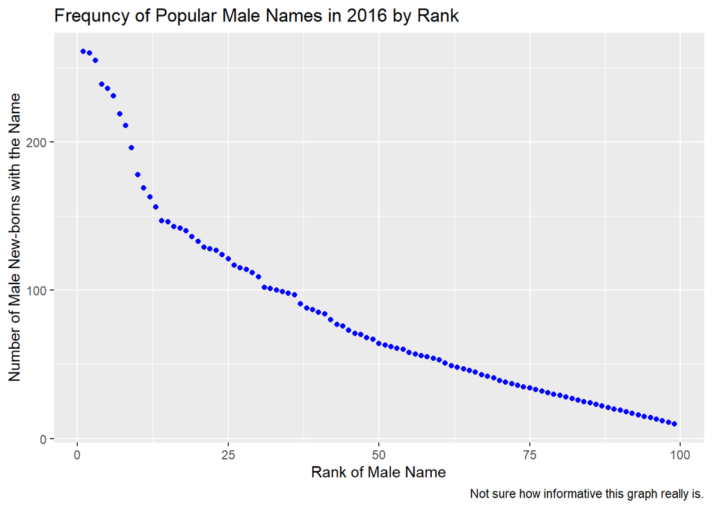

```r
baby_names %>%
  filter(year_of_birth=="2016",ethnicity=="WHITE NON HISPANIC",gender=="MALE") %>%
  ggplot(aes(x=rank,y=count))+
    geom_point(color="blue")+
  labs(
    title = "Frequncy of Popular Male Names in 2016 by Rank",
    x = "Rank of Male Name",
    y = "Number of Male New-borns with the Name",
    caption = "Not sure how informative this graph really is."
  )
```